# HW 1: Reidentification, Reconstruction and Membership Attacks

Bhaven Patel

2/26/2019

I collaborated Anthony Rentsch and Lipika Ramaswamy on this homework.

## 1. Reidentification Attack

To perform a reidentification attack on this PUMS dataset from the 2000 Census, I could obtain the Georgia voter registration file, which contains an individual’s residential address, year of birth, gender, and race ([Georgia’s voter registration list](http://sos.ga.gov/index.php/elections/order_voter_registration_lists_and_files)). The individual’s residential address could be used to identify which PUMA code he or she belongs to. A voter’s “year of birth” would be used to calculate his/her age, while race would be used to match against the “latino”, “black”, and “asian” features we have in the PUMA dataset. Lastly, a voter’s gender would be used to match against the “sex” feature in the PUMA dataset.  
Assuming the individuals from the voter registration file are also in the 5% PUMA sample, I was able to uniquely identify 598 individuals in the PUMA dataset based on the available features from the voter registration file. This translated to reidentifying 2.3% of the individuals in the dataset.  
Below is my code for performing the reidentification attack. It can also be accessed on [Github](https://github.com/bhavenp/cs208/blob/master/homework/HW1/HW1_1.R).

```
library(plyr);
library(dplyr);

#read in the PUMS
data <- read.csv("../../data/FultonPUMS5full.csv");

#groupby PUMA region, age, sex, and race in data
data_gb <- data %>% group_by(puma, sex, age, latino, black, asian) %>% summarise(n=n());
#get rows of groupby where we only have unique individuals
unique_indivs <- data_gb[data_gb$n == 1, ];
print(nrow(unique_indivs))
#calculate the percent of people that I could uniquely
perc_unq <- nrow(unique_indivs) / nrow(data);
print(perc_unq)
```

## 2. Reconstruction Attack

Below are graphs illustrating how adding “Rounding” noise to the answers to the queries in a reconstruction attack affects the RMSE of the answer and the accuracy of the reconstruction. The dashed blue line is drawn at 0.5, which is when the reconstruction attack fails because the attacker should be able to achieve an accuracy of 0.5 by simply flipping a coin to generate the sensitive bit for each individual.

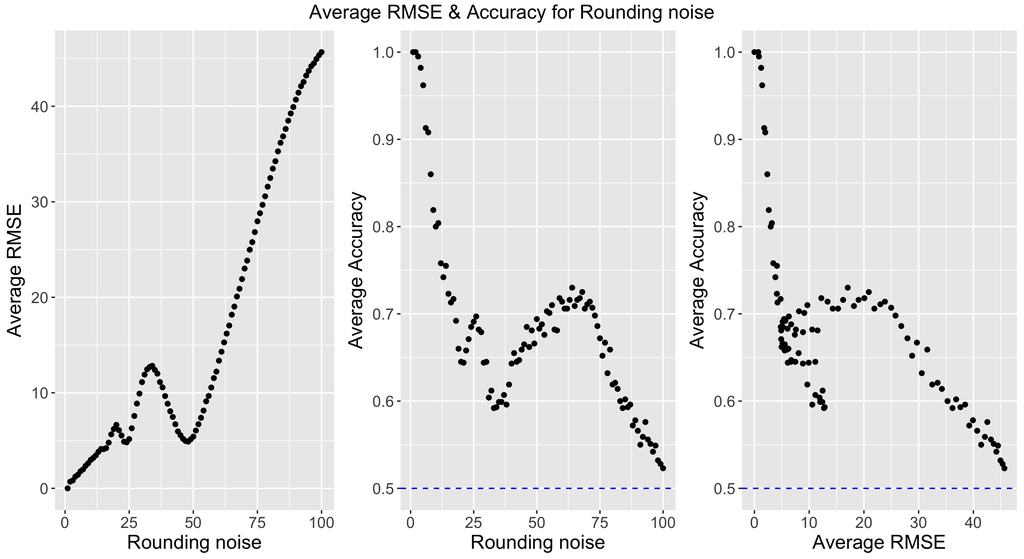

We see that as the “Rounding” noise increases, for the most part the RMSE of the answer also increases and the accuracy of the reconstruction decreases. There is an interesting increase in accuracy from ~30 to ~60 in the “Rounding” noise parameter because for most of the random subsets, the true sum of the sensitive bit (US Citizen) was around 50. Thus, the noisy answers are close to their true sum, as seen by the dip in RMSE from noise parameters ~30 to ~60 in the first graph. This occurrence causes the “Accuracy vs. RMSE” graph to have a unique shape where there is a cluster of points with an RMSE of ~5-12 and an accuracy between 60% adn 70%. Using a noise parameter of 100 for “Rounding” limits the attacker to achieving just baseline accuracy on the reconstruction, but it also provides very little utility.  
Below are graphs illustrating how adding “Gaussian” noise to the answers to the queries in a reconstruction attack affects the RMSE of the answer and the accuracy of the reconstruction. The dashed blue line is drawn at 0.5 to indicate baseline accuracy for the attacker.

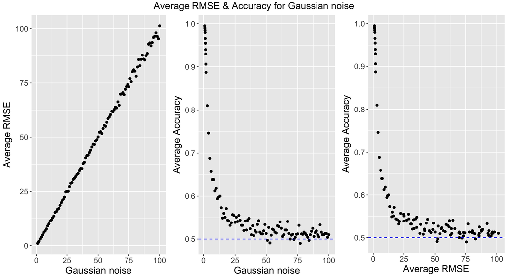

As expected, as Gaussian noise increases, the RMSE between the true value and the noisy answer increases and accuracy of reconstruction decreases; the relationship between RMSE and accuracy could be described as exponential decay. The accuracy of reconstruction drops very quickly even with adding noise from a Gaussian distribution with small standard deviations of 1.5-3. Noise parameters of 11 standard deviations and greater for “Gaussian” noise limit the attacker to achieving no more than 60% accuracy on the reconstruction attack, however the utility decreases as more Gaussian noise is added.

Below are graphs illustrating how adding noise using “Subsampling” to the generate noisy answers to the queries in a reconstruction attack affects the RMSE of the answer and the accuracy of the reconstruction. The dashed blue line is drawn at 0.5 to indicate the baseline accuracy for reconstruction.

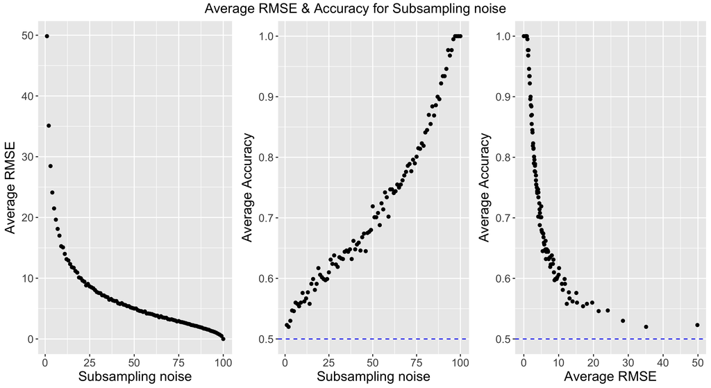

As expected, as the “Subsampling” size increases, the RMSE of the answers decreases and the accuracy increases since the noisy count better approximates the true count with larger subsample sizes. The accuracy increases almost linearly, which was interesting to see since I expected an exponential increase. Like with the “Gaussian” noise, the relationship between RMSE and accuracy can be described by a exponential decay. Using a noisy parameter of 50 for “Subsampling” allows the attacker to achieve ~70% reconstruction accuracy and only an RMSE of ~5, providing some privacy and utility.  
The code for my reconstruction attack can be accessed on [Github](https://github.com/bhavenp/cs208/blob/master/homework/HW1/HW1_2.R) and is displayed below.

```
library(plyr); #import this library for doing rounding for noise
library(ggplot2); #import library for plotting
library(grid);

#### Parameters ####
prime <- 113; # prime number for hashing creating random vectors to pass to query
n <- 100;        # Dataset size
k.trials <- 2*n;  # Number of queries
num_exps <- 10; #number of experiments
noise_input <- "Subsampling"; # What type of noise will be used as defense. Can be "Rounding", "Gaussian", or "Subsampling"

noise_vec <- c(1:100); #noise parameters for Rounding and Subsampling
# noise_vec <- c(seq(1, 1.9, 0.1), 2:100); #noise parameters for Gaussian


#### Import Data ####
pums_100 <- read.csv(file="../../data/FultonPUMS5sample100.csv"); #read in data from data folder
#trim dataset to only the PUB categories plus "uscitizen"
pums_100_trimmed <- pums_100[, c("sex", "age", "educ","income", "latino", "black", "asian",  "married", "divorced", "children", "employed", "militaryservice", "disability", "englishability", "uscitizen")];

#### Query function ####
query <- function(random_vec, data, prime, noise_type, noise_param){
  data_mat <- data.matrix(data[, 1:14]); # convert all rows and PUB categories into matrix
  #multiply matrix by random vector and
  person_in_sum <- (data_mat %*% random_vec) %% prime %% 2;
  us_citz_sum <- sum(person_in_sum * data[, 15]);

  if(noise_type == "Rounding"){
    noisy_sum <- round_any(us_citz_sum, noise_param); #this function will round the sum according to a multiple of noise_param
  }
  else if(noise_type == "Gaussian"){
    noisy_sum <- us_citz_sum + rnorm(n=1, mean=0, sd=noise_param); #add noise sampled by from N(0, noise_param)
  }
  else{
    subsamp_ind <- sample(x=1:length(person_in_sum), size=noise_param, replace=FALSE); #get a random sample of the indices w/o replacement
    subsamp_sum <- sum(person_in_sum[subsamp_ind] * data[subsamp_ind, 15]); #get the US citizen count for the subsample
    noisy_sum <- subsamp_sum * (n / noise_param); #sum to report will be subsamp_sum x (scaling factor)
  }

  # return the actual sum, the noisy sum and indices. I am returning the indices here so that I don't have to recalculate which individuals were included in the sum.
```

[output cut: 70 more lines]

```
p_acc <- p_acc + geom_hline(yintercept = fifty, linetype="dashed", color = "blue");
p_acc <- p_acc + labs(x=paste(noise_input, "noise"), y = "Average Accuracy") + theme(plot.title = element_text(hjust=0.5), text = element_text(size=f_size));
# Plot average RMSE vs average accuracy of reconstruction
p_rmse_acc <- ggplot(data = final_results, aes(x=final_results$RMSE, y=final_results$Acc)) + geom_point();
p_rmse_acc <- p_rmse_acc + geom_hline(yintercept = fifty, linetype="dashed", color = "blue");
p_rmse_acc <- p_rmse_acc + labs(x="Average RMSE", y = "Average Accuracy") + theme(plot.title = element_text(hjust=0.5), text = element_text(size=f_size));

#create grid for plotting
gs <- grid.arrange(p_rmse, p_acc, p_rmse_acc, nrow=1, ncol=3, top=textGrob(paste("Average RMSE & Accuracy for",noise_input,"noise"), gp=gpar(fontsize=15)) );

#### Export the graph
ggsave(filename = paste("./figs/regAttack", noise_input, "noise.jpg", sep = "_"), plot=gs, width = 11, height = 6);

#### Save data so I don't have to run the simualtion again if I want to re-plot the data
write.csv(final_results, paste("./regAttack", noise_input, "noise.csv", sep = "_"));
```

## 3. Membership Attack

The graph below shows the results of my “Rounding” defense using a noise parameter of 100 against the membership attack as the number of attributes available to the attacker increases. I round the sum of each column in the sample dataset to a multiple of 100 before calculating the mean because 100 was the value at which the reconstruction attack failed. My false-positive rate false-positive rate ($\alpha$) was set to 0.001.

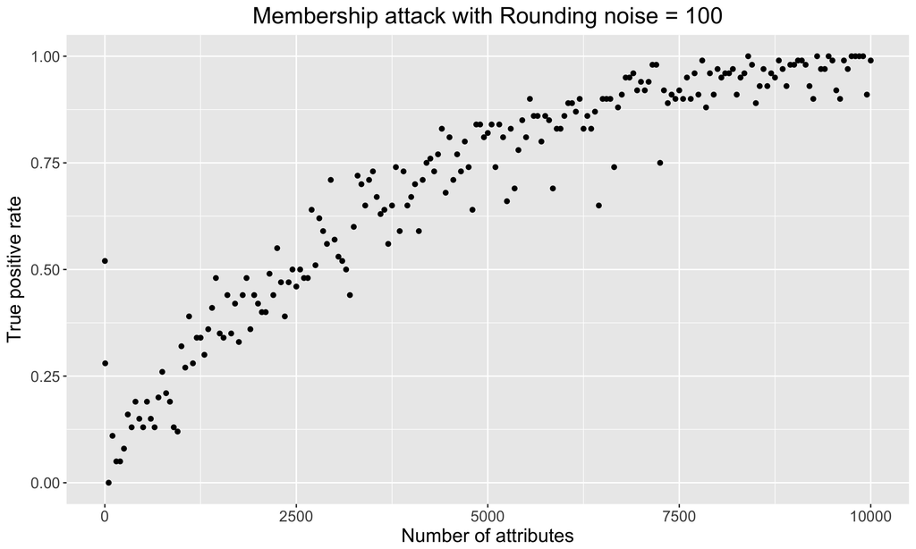

It takes almost about 2500 attributes before the attacker can correctly identify about 50% of the individuals in the sample, and the attacker approaches 100% identification as the number of attributes approaches 10,000, since our error per query is $\sqrt{n}$ where $n$ is the number of attributes/queries.  
Below are graphs showing the results of my “Gaussian” defense using a noise parameter of 11 (standard deviations) against the membership attack as the number of attributes available to the attacker increases. I add a different amount of noise (sampled from a Gaussian distribution with mean 0 and standard deviation 11) to the sum of each column in the sample dataset before calculating the mean. With a Gaussian noise of 11, the reconstruction attack achieve ~60% accuracy and allows the membership attack to demonstrate how accuracy increases with more attributes. My $\alpha$ was set to 0.001.

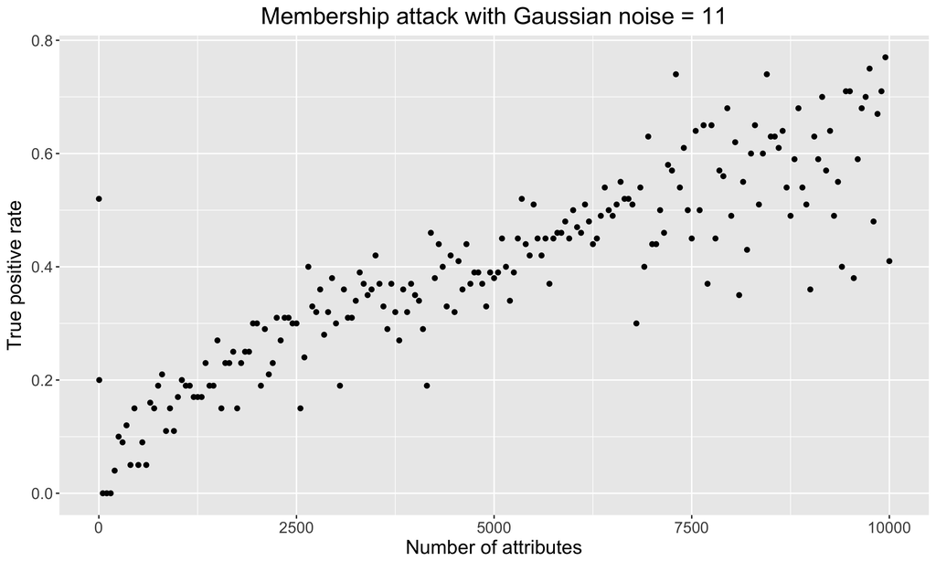

Unlike with the “Rounding”" noise, the membership attack does not achieve 100% accuracy with Gaussian noise, but accuracy does increase as the number of attributes available to the attacker increases. The true positive rate maxes out at close to 80%. I would have expected the membership attack to achieve close to 100% near 10,000 attributes.  
Below are graphs showing the results of my “Subsampling” defense using a noise parameter of 50 against the membership attack as the number of attributes available to the attacker increases. To generate means for the columns in the sample, I subsample 50 individuals from the sample and then report the means of the columns for just those 50 individuals. I used 50 as my noise parameter for “Subsampling” because it also allowed me to see how accuracy of the membership attack ranged with the number of attributes. My false-positive rate ($\alpha$) was set to 0.001.

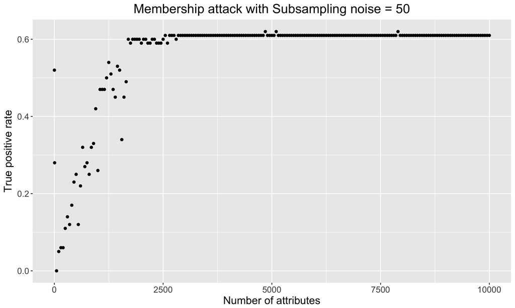

Unlike the other defenses, the membership attack accuracy increases very quickly for lower number of attributes and then maxes out at 60% after ~2000 attributes are used. It is somewhat successful since the true-positive rate surpasses 50%. Thus even with 10,000 attributes, the membership attack fails to get close to 100% accuracy.  
The code for my membership attack can be accessed on [Github](https://github.com/bhavenp/cs208/blob/master/homework/HW1/HW1_3.R) and and is displayed below.

```
library(plyr); #import this library for doing rounding for noise
library(ggplot2); #import library for plotting
library(gridExtra);

#### Parameters ####
prime <- 113; # prime number for hashing creating random vectors to pass to query
n <- 100;        # Dataset size
num_attr <- n*n; #calculate the number of attributes needed
noise_type <- "Subsampling"; # What type of noise will be used as defense. Can be "Rounding", "Gaussian", or "Subsampling"
# noise_val <- 100; #noise to introduce for Rounding
# noise_val <- 11; #noise to introduce for Gaussian
noise_val <- 50; #noise to introduce for Subsampling


#### Import Data ####
pums_full <- read.csv(file = "../../data/FultonPUMS5full.csv"); #read in the full data
#trim the population to PUB categories
pums_full_trimmed <- pums_full[, c("sex", "age", "educ", "latino", "black", "asian",  "married", "divorced", "children", "employed", "militaryservice", "disability", "englishability")];
pums_100 <- read.csv(file="../../data/FultonPUMS5sample100.csv"); #read in sample data from data folder
#trim sample to only PUB cols
pums_100_trimmed <- pums_100[, c("sex", "age", "educ", "latino", "black", "asian",  "married", "divorced", "children", "employed", "militaryservice", "disability", "englishability")];
#--------------------------------------------------------------------#

#### Do some cleaning of the data ####
#dummify age by comparing each individual's age to the mean
pums_full_trimmed$age <- ifelse(pums_full_trimmed$age > mean(pums_full_trimmed$age), 1, 0);
pums_100_trimmed$age <- ifelse(pums_100_trimmed$age > mean(pums_full_trimmed$age), 1, 0);

#dummify education column in the population and sample
for(e in unique(pums_full_trimmed$educ)){
  pums_full_trimmed[paste("educ", e, sep = "_")] <- ifelse(pums_full_trimmed$educ == e, 1, 0);
  pums_100_trimmed[paste("educ", e, sep = "_")] <- ifelse(pums_100_trimmed$educ == e, 1, 0);
}
#remove the education column in the population and sample
pums_full_trimmed <- subset(pums_full_trimmed, select = -c(educ));
pums_100_trimmed <- subset(pums_100_trimmed, select = -c(educ)); #remove the education column

#generate random predicates
preds_to_add <- as.matrix( replicate(num_attr-ncol(pums_full_trimmed), sample(0:prime-1, size=ncol(pums_full_trimmed)), simplify=TRUE) );

```

[output cut: 101 more lines]

```



#### Plot results ####
f_size = 15;
history <- as.data.frame(history);
colnames(history) <- c("num_attr", "tpr", "crit_val");
# Plot average RMSE of reconstruction against noise input
p <- ggplot(data = history, aes(x=history$num_attr, y=history$tpr)) + geom_point();
p <- p + labs(title = paste("Membership attack with", noise_type, "noise =", noise_val), x="Number of attributes", y = "True positive rate") + theme(plot.title = element_text(hjust=0.5), text = element_text(size=f_size));

#### Export the graph
ggsave(filename = paste("./figs/memAttack", noise_type, "noise.jpg", sep = "_"), plot=p, width = 10, height = 6);
#### Save data so I don't have to run the simualtion again if I want to re-plot the data
write.csv(history, paste("./memAttack", noise_type, "noise.csv", sep = "_"));
```

## 4. Final Project Ideas

Anthony Rentsch and I will be working together for the final project. We are interested in implementing an attack on a real-life dataset that contains some potentially sensitive information, especially datasets from the social and life sciences (i.e., medical records, political surveys). After implementing an attack, we would formulate a strategy for a differentially private algorithm/mechanism that could be used to preserve individual privacy while also enabling researchers to gain utility for different use cases, including descriptive queries and inferential/predictive modeling. Specifically, we would be interested in seeing how a differentially private algorithm affects the performance of machine learning models. We would also be interested in examining how a differentially private algorithm could be implemented in a publicly available application that provides useful diagnostic information; for instance, we could use the City of Boston’s public 311 service requests or Field Interrogation and Observation data (similar to stop-and-frisk data) to provide updates on the current safety/well-being of different neighborhoods, while limiting any privacy loss.